# Módulo 6

# PROYECTO 2

# Filtros sobre Imágenes

## Gretel Fernanda Trejo Hernandez

El procesamiento de imágenes mediante redes neuronales es una técnica ampliamente utilizada en la clasificación automática de contenido visual. En este proyecto, se utiliza un conjunto de datos de imágenes de vehículos descargado desde Kaggle, con el objetivo de aplicar un preprocesamiento básico (normalización) y construir una red neuronal convolucional para clasificar las imágenes en distintas categorías.

Además de entrenar un modelo de aprendizaje profundo, el enfoque principal está en el preprocesamiento de las imágenes, aplicando técnicas como la normalización y la visualización de muestras. Estas etapas permiten mejorar el desempeño del modelo y entender mejor la información visual contenida en los datos.

### Justificación del filtro elegido

En este proyecto se utilizó una técnica de normalización como filtro principal. La normalización consiste en escalar los valores de los pixeles de las imágenes del rango original [0, 255] al rango [0, 1]. Este tipo de preprocesamiento es fundamental en redes neuronales, ya que mejora la estabilidad numérica durante el entrenamiento, acelera la convergencia del modelo y reduce la posibilidad de saturación en las funciones de activación.

Se muestra primero el modelo normalizado, para posteriormente implementarlo sin normalizar, con el objetivo de comparar su precisión.

### Clasificación de imágenes

Se empleó una arquitectura secuencial con capas convolucionales, max pooling, y capas densas, lo que permitió alcanzar buenos resultados de precisión en la tarea de clasificación. El conjunto de datos fue dividido en entrenamiento y validación, lo cual permitió evaluar el rendimiento del modelo de forma adecuada.

```python
import numpy as np
import pandas as pd
import matplotlib.pyplot as plt
from tensorflow import keras
from tensorflow.keras import layers
from tensorflow.keras.utils import to_categorical
```

```python
!pip install kagglehub
```

#### Modelo Normalizado

```python
import kagglehub
import tensorflow as tf

# Descargar el dataset
path = kagglehub.dataset_download("lyensoetanto/vehicle-images-dataset")

# Cargar el dataset desde el directorio descargado
train_ds = tf.keras.utils.image_dataset_from_directory(
    path,
    validation_split=0.2,
    subset="training",
    seed=123,
    image_size=(128, 128),
    batch_size=32
)

val_ds = tf.keras.utils.image_dataset_from_directory(
    path,
    validation_split=0.2,
    subset="validation",
    seed=123,
    image_size=(128, 128),
    batch_size=32
)
```

```
Found 15645 files belonging to 7 classes.
Using 12516 files for training.
Found 15645 files belonging to 7 classes.
Using 3129 files for validation.
```

```python
# Ver las clases
class_names = train_ds.class_names
print(class_names)
print(f"Número de clases: {len(class_names)}")
```

```
['Big Truck', 'City Car', 'Multi Purpose Vehicle', 'Sedan', 'Sport Utility Vehicle', 'Truck', 'Van']
Número de clases: 7
```

```python
# Normalizar las imágenes (de 0-255 a 0-1)
normalization_layer = tf.keras.layers.Rescaling(1./255)
train_ds = train_ds.map(lambda x, y: (normalization_layer(x), y))
val_ds = val_ds.map(lambda x, y: (normalization_layer(x), y))
```

[figure not shown]

```python
# Extraer una cantidad pequeña de datos para visualización
for images, labels in train_ds.take(1):
    plt.figure(figsize=(10, 10))
    for i in range(min(25, len(images))):
        plt.subplot(5, 5, i + 1)
        img = (images[i].numpy() * 255).astype("uint8")  # Escalar si fueron normalizadas
        plt.imshow(img)
        plt.title(f"Etiqueta: {labels[i].numpy()}")
        plt.axis("off")
    plt.tight_layout()
    plt.show()
```

```python
# Convertir las etiquetas a one-hot encoding correctamente
def one_hot_map(x, y):
    y = to_categorical(y, num_classes=7)
    return x, y

train_ds = train_ds.map(one_hot_map)
val_ds = val_ds.map(one_hot_map)

# Ahora las etiquetas están en formato one-hot encoding
```

```python
# Modelo Convolucional
model = tf.keras.Sequential([
    # Capa convolucional 1
    tf.keras.layers.Conv2D(32, kernel_size=(3, 3), activation='relu', input_shape=(128, 128, 3)),
    # Capa pooling
    tf.keras.layers.MaxPooling2D(pool_size=(2, 2)),
    # Segunda capa convolucional 64 filtros
    tf.keras.layers.Conv2D(64, kernel_size=(3, 3), activation='relu'),
    # Capa pooling 2
    tf.keras.layers.MaxPooling2D(pool_size=(2, 2)),
    # Aplanar los mapas de características
    tf.keras.layers.Flatten(),
    # Capa densa 128 neuronas
    tf.keras.layers.Dense(128, activation='relu'),
    # Regularización
    tf.keras.layers.Dropout(0.2),
    # Capa de salida con 10 neuronas (una para cada clase)
    tf.keras.layers.Dense(7, activation='softmax')
])

model.summary()
```

```
Model: "sequential"
```

```
┏━━━━━━━━━━━━━━━━━━━━━━━━━━━━━━━━━━━━━━┳━━━━━━━━━━━━━━━━━━━━━━━━━━━━━┳━━━━━━━━━━━━━━━━━┓
┃ Layer (type)                         ┃ Output Shape                ┃         Param # ┃
┡━━━━━━━━━━━━━━━━━━━━━━━━━━━━━━━━━━━━━━╇━━━━━━━━━━━━━━━━━━━━━━━━━━━━━╇━━━━━━━━━━━━━━━━━┩
│ conv2d (Conv2D)                      │ (None, 126, 126, 32)        │             896 │
├──────────────────────────────────────┼─────────────────────────────┼─────────────────┤
│ max_pooling2d (MaxPooling2D)         │ (None, 63, 63, 32)          │               0 │
├──────────────────────────────────────┼─────────────────────────────┼─────────────────┤
│ conv2d_1 (Conv2D)                    │ (None, 61, 61, 64)          │          18,496 │
├──────────────────────────────────────┼─────────────────────────────┼─────────────────┤
│ max_pooling2d_1 (MaxPooling2D)       │ (None, 30, 30, 64)          │               0 │
├──────────────────────────────────────┼─────────────────────────────┼─────────────────┤
│ flatten (Flatten)                    │ (None, 57600)               │               0 │
├──────────────────────────────────────┼─────────────────────────────┼─────────────────┤
│ dense (Dense)                        │ (None, 128)                 │       7,372,928 │
├──────────────────────────────────────┼─────────────────────────────┼─────────────────┤
│ dropout (Dropout)                    │ (None, 128)                 │               0 │
├──────────────────────────────────────┼─────────────────────────────┼─────────────────┤
│ dense_1 (Dense)                      │ (None, 7)                   │             903 │
└──────────────────────────────────────┴─────────────────────────────┴─────────────────┘
```

```
 Total params: 7,393,223 (28.20 MB)
```

```
 Trainable params: 7,393,223 (28.20 MB)
```

```
 Non-trainable params: 0 (0.00 B)
```

```python
## COMPILACION DEL MODELO
model.compile(
    optimizer='adam',
    loss='categorical_crossentropy',
    metrics=['accuracy']
)
```

```python
#Entrenar el modelo
batch_size = 128
epochs = 10

history = model.fit(
    train_ds,  # Usamos el dataset de entrenamiento
    epochs=epochs,
    validation_data=val_ds,  # Usamos el dataset de validación
    batch_size=batch_size  # Este argumento es opcional si ya se ha definido en los datasets
)
```

```
392/392 ━━━━━━━━━━━━━━━━━━━━ 119s 297ms/step - accuracy: 0.3439 - loss: 1.7290 - val_accuracy: 0.5487 - val_loss: 1.1101
392/392 ━━━━━━━━━━━━━━━━━━━━ 122s 311ms/step - accuracy: 0.5739 - loss: 1.0589 - val_accuracy: 0.6127 - val_loss: 0.9811
392/392 ━━━━━━━━━━━━━━━━━━━━ 133s 338ms/step - accuracy: 0.6916 - loss: 0.7864 - val_accuracy: 0.7057 - val_loss: 0.7724
392/392 ━━━━━━━━━━━━━━━━━━━━ 145s 347ms/step - accuracy: 0.7964 - loss: 0.5340 - val_accuracy: 0.7453 - val_loss: 0.7189
392/392 ━━━━━━━━━━━━━━━━━━━━ 140s 356ms/step - accuracy: 0.8475 - loss: 0.4217 - val_accuracy: 0.7718 - val_loss: 0.7289
392/392 ━━━━━━━━━━━━━━━━━━━━ 136s 346ms/step - accuracy: 0.9057 - loss: 0.2542 - val_accuracy: 0.7645 - val_loss: 0.8504
392/392 ━━━━━━━━━━━━━━━━━━━━ 138s 351ms/step - accuracy: 0.9283 - loss: 0.2050 - val_accuracy: 0.7322 - val_loss: 0.9754
392/392 ━━━━━━━━━━━━━━━━━━━━ 136s 346ms/step - accuracy: 0.9375 - loss: 0.1757 - val_accuracy: 0.7721 - val_loss: 0.8560
392/392 ━━━━━━━━━━━━━━━━━━━━ 137s 350ms/step - accuracy: 0.9598 - loss: 0.1200 - val_accuracy: 0.7897 - val_loss: 0.8787
392/392 ━━━━━━━━━━━━━━━━━━━━ 139s 353ms/step - accuracy: 0.9651 - loss: 0.1031 - val_accuracy: 0.7935 - val_loss: 0.8743
```

```python
test_loss, test_acc = model.evaluate(val_ds, verbose=0)
print(f"\nPrecisión en el conjunto de prueba: {test_acc:.4f}")
```

```
Precisión en el conjunto de prueba: 0.7935
```

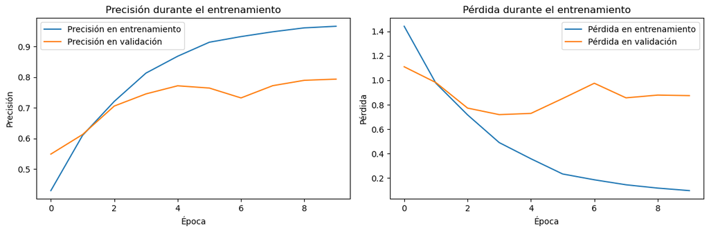

```python
import matplotlib.pyplot as plt

# Verifica que las métricas de precisión y pérdida están presentes
if 'accuracy' in history.history and 'val_accuracy' in history.history:
    plt.figure(figsize=(12, 4))  # Gráfica de precisión durante el entrenamiento
    plt.subplot(1, 2, 1)
    plt.plot(history.history['accuracy'], label='Precisión en entrenamiento')
    plt.plot(history.history['val_accuracy'], label='Precisión en validación')
    plt.title('Precisión durante el entrenamiento')
    plt.xlabel('Época')
    plt.ylabel('Precisión')
    plt.legend()

if 'loss' in history.history and 'val_loss' in history.history:
    plt.subplot(1, 2, 2)  # Gráfica de pérdida durante el entrenamiento
    plt.plot(history.history['loss'], label='Pérdida en entrenamiento')
    plt.plot(history.history['val_loss'], label='Pérdida en validación')
    plt.title('Pérdida durante el entrenamiento')
    plt.xlabel('Época')
    plt.ylabel('Pérdida')
    plt.legend()

# Mostrar las gráficas
plt.tight_layout()
plt.show()
```

```
98/98 ━━━━━━━━━━━━━━━━━━━━ 9s 84ms/step
```

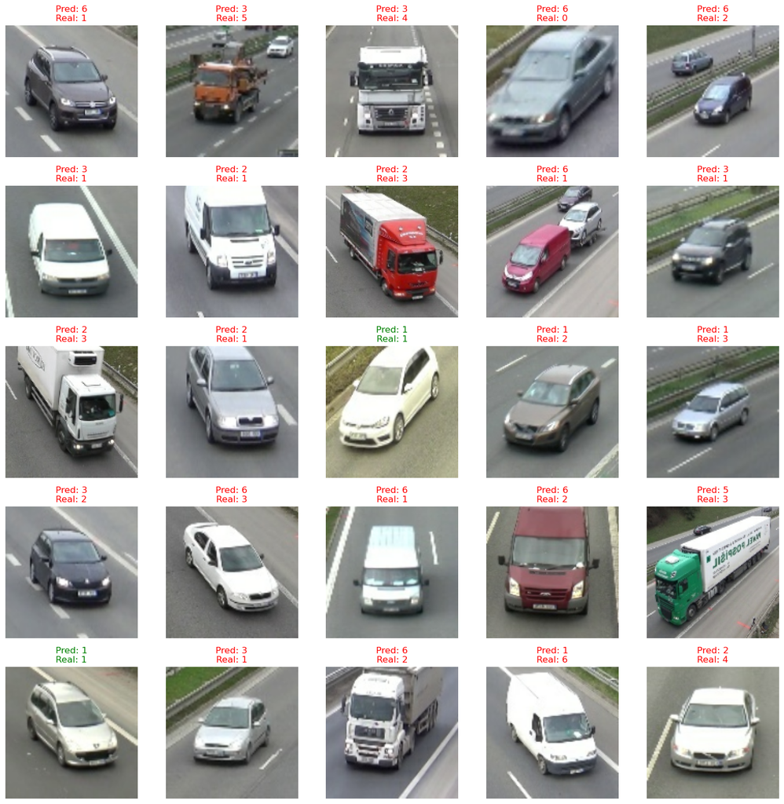

```python
# Realizar predicciones
predictions = model.predict(val_ds)
predicted_labels = np.argmax(predictions, axis=1)  # Convertir las predicciones a etiquetas

# Extraer etiquetas verdaderas desde val_ds
true_labels = []
for image, label in val_ds.unbatch():  # Unbatch para iterar sobre el dataset
    true_labels.append(label.numpy())  # Convertir las etiquetas a numpy array
true_labels = np.array(true_labels)
true_labels = np.argmax(true_labels, axis=1)  # Convertir las etiquetas verdaderas a formato numérico

# Configurar la figura para mostrar las imágenes
plt.figure(figsize=(15, 15))

# Mostrar las primeras 25 imágenes y sus predicciones
for i, (image, label) in enumerate(val_ds.unbatch().take(25)):  # Iterar sobre las imágenes del conjunto de validación
    plt.subplot(5, 5, i + 1)
    plt.imshow(image.numpy().squeeze(), cmap='gray')  # Mostrar imagen
    color = 'green' if predicted_labels[i] == true_labels[i] else 'red'  # Color para predicción correcta o incorrecta
    plt.title(f"Pred: {predicted_labels[i]}\nReal: {true_labels[i]}", color=color)
    plt.axis('off')  # Desactivar los ejes para mejor visualización

plt.tight_layout()  # Ajustar para evitar solapamiento
plt.show()
```

[output not shown]

[output cut: 43 more lines]

[output not shown]

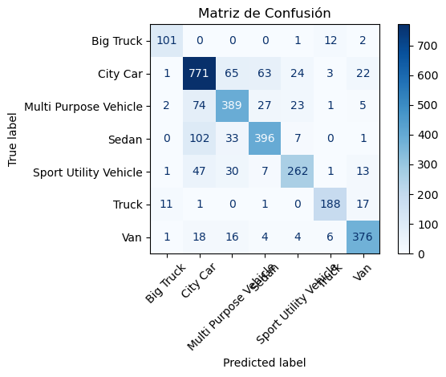

```python
from sklearn.metrics import confusion_matrix, ConfusionMatrixDisplay

# Obtener todas las predicciones del set de validación
y_true = []
y_pred = []

for images, labels in val_ds:
    preds = model.predict(images)
    y_pred.extend(tf.argmax(preds, axis=1).numpy())
    y_true.extend(tf.argmax(labels, axis=1).numpy())

# Crear matriz de confusión
cm = confusion_matrix(y_true, y_pred)
disp = ConfusionMatrixDisplay(confusion_matrix=cm, display_labels=class_names)
disp.plot(xticks_rotation=45, cmap='Blues')
plt.title("Matriz de Confusión")
plt.tight_layout()
plt.show()
```

#### Modelo sin Normalizar

```python
train_ds_raw = tf.keras.utils.image_dataset_from_directory(
    path,
    validation_split=0.2,
    subset="training",
    seed=123,
    image_size=(128, 128),
    batch_size=32
)

val_ds_raw = tf.keras.utils.image_dataset_from_directory(
    path,
    validation_split=0.2,
    subset="validation",
    seed=123,
    image_size=(128, 128),
    batch_size=32
)

# One-hot encoding
train_ds_raw = train_ds_raw.map(one_hot_map)
val_ds_raw = val_ds_raw.map(one_hot_map)
```

```
Found 15645 files belonging to 7 classes.
Using 12516 files for training.
Found 15645 files belonging to 7 classes.
Using 3129 files for validation.
```

```python
# Crear un nuevo modelo (igual que el anterior)
model_raw = tf.keras.Sequential([
    tf.keras.layers.Conv2D(32, (3, 3), activation='relu', input_shape=(128, 128, 3)),
    tf.keras.layers.MaxPooling2D((2, 2)),
    tf.keras.layers.Conv2D(64, (3, 3), activation='relu'),
    tf.keras.layers.MaxPooling2D((2, 2)),
    tf.keras.layers.Flatten(),
    tf.keras.layers.Dense(128, activation='relu'),
    tf.keras.layers.Dense(7, activation='softmax')  # 10 clases
])

model_raw.compile(optimizer='adam',
              loss='categorical_crossentropy',
              metrics=['accuracy'])

# Entrenar el modelo
history_raw = model_raw.fit(train_ds_raw, validation_data=val_ds_raw, epochs=10)
```

```
392/392 ━━━━━━━━━━━━━━━━━━━━ 144s 351ms/step - accuracy: 0.2717 - loss: 31.1159 - val_accuracy: 0.4455 - val_loss: 1.4213
392/392 ━━━━━━━━━━━━━━━━━━━━ 133s 340ms/step - accuracy: 0.4974 - loss: 1.2770 - val_accuracy: 0.5062 - val_loss: 1.3477
392/392 ━━━━━━━━━━━━━━━━━━━━ 134s 342ms/step - accuracy: 0.6092 - loss: 1.0014 - val_accuracy: 0.5487 - val_loss: 1.3819
392/392 ━━━━━━━━━━━━━━━━━━━━ 135s 344ms/step - accuracy: 0.7670 - loss: 0.6252 - val_accuracy: 0.5788 - val_loss: 1.4917
392/392 ━━━━━━━━━━━━━━━━━━━━ 132s 337ms/step - accuracy: 0.8630 - loss: 0.3819 - val_accuracy: 0.5676 - val_loss: 1.7482
392/392 ━━━━━━━━━━━━━━━━━━━━ 119s 302ms/step - accuracy: 0.9149 - loss: 0.2473 - val_accuracy: 0.6261 - val_loss: 1.9389
392/392 ━━━━━━━━━━━━━━━━━━━━ 132s 337ms/step - accuracy: 0.9401 - loss: 0.1781 - val_accuracy: 0.6296 - val_loss: 2.0373
392/392 ━━━━━━━━━━━━━━━━━━━━ 134s 342ms/step - accuracy: 0.9518 - loss: 0.1561 - val_accuracy: 0.6203 - val_loss: 2.4818
392/392 ━━━━━━━━━━━━━━━━━━━━ 134s 341ms/step - accuracy: 0.9525 - loss: 0.1536 - val_accuracy: 0.6421 - val_loss: 2.6800
392/392 ━━━━━━━━━━━━━━━━━━━━ 134s 341ms/step - accuracy: 0.9676 - loss: 0.1124 - val_accuracy: 0.6280 - val_loss: 2.6277
```

```python
# Evaluar el modelo
test_loss_raw, test_acc_raw = model_raw.evaluate(val_ds_raw, verbose=0)
print(f"\nPrecisión en el conjunto de prueba (sin normalización): {test_acc_raw:.4f}")
```

```
Precisión en el conjunto de prueba (sin normalización): 0.6280
```

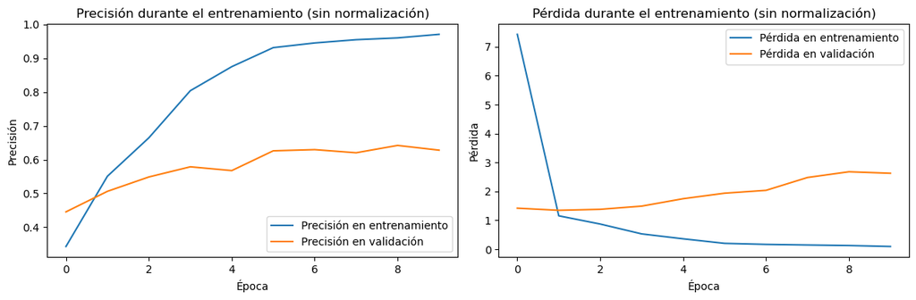

```python
# Verificar las métricas en el historial del modelo
if 'accuracy' in history_raw.history and 'val_accuracy' in history_raw.history:
    plt.figure(figsize=(12, 4))
    plt.subplot(1, 2, 1)
    plt.plot(history_raw.history['accuracy'], label='Precisión en entrenamiento')
    plt.plot(history_raw.history['val_accuracy'], label='Precisión en validación')
    plt.title('Precisión durante el entrenamiento (sin normalización)')
    plt.xlabel('Época')
    plt.ylabel('Precisión')
    plt.legend()

if 'loss' in history_raw.history and 'val_loss' in history_raw.history:
    plt.subplot(1, 2, 2)
    plt.plot(history_raw.history['loss'], label='Pérdida en entrenamiento')
    plt.plot(history_raw.history['val_loss'], label='Pérdida en validación')
    plt.title('Pérdida durante el entrenamiento (sin normalización)')
    plt.xlabel('Época')
    plt.ylabel('Pérdida')
    plt.legend()

plt.tight_layout()
plt.show()
```

```
98/98 ━━━━━━━━━━━━━━━━━━━━ 8s 79ms/step
```

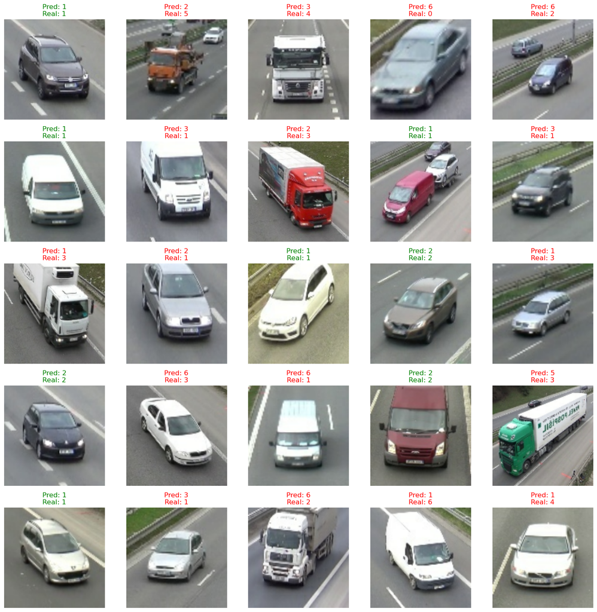

```python
# Realizar predicciones con el modelo
predictions_raw = model_raw.predict(val_ds_raw)
predicted_labels_raw = np.argmax(predictions_raw, axis=1)

# Etiquetas verdaderas
true_labels_raw = []
for image, label in val_ds_raw.unbatch():
    true_labels_raw.append(label.numpy())
true_labels_raw = np.array(true_labels_raw)
true_labels_raw = np.argmax(true_labels_raw, axis=1)

# Mostrar imágenes y predicciones
plt.figure(figsize=(15, 15))
for i, (image, label) in enumerate(val_ds_raw.unbatch().take(25)):
    plt.subplot(5, 5, i + 1)
    plt.imshow(image.numpy().squeeze().astype("uint8"))  # sin normalizar, ya están en 0–255
    color = 'green' if predicted_labels_raw[i] == true_labels_raw[i] else 'red'
    plt.title(f"Pred: {predicted_labels_raw[i]}\nReal: {true_labels_raw[i]}", color=color)
    plt.axis('off')

plt.tight_layout()
plt.show()
```

[output not shown]

[output cut: 43 more lines]

[output not shown]

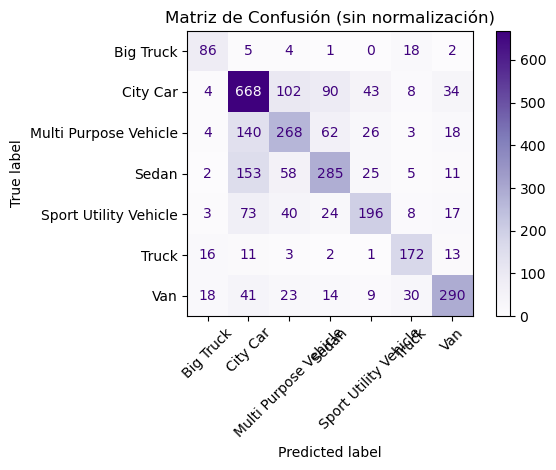

```python
y_true_raw = []
y_pred_raw = []

for images, labels in val_ds_raw:
    preds = model_raw.predict(images)
    y_pred_raw.extend(tf.argmax(preds, axis=1).numpy())
    y_true_raw.extend(tf.argmax(labels, axis=1).numpy())

# Matriz de confusión
cm_raw = confusion_matrix(y_true_raw, y_pred_raw)
disp_raw = ConfusionMatrixDisplay(confusion_matrix=cm_raw, display_labels=class_names)
disp_raw.plot(xticks_rotation=45, cmap='Purples')
plt.title("Matriz de Confusión (sin normalización)")
plt.tight_layout()
plt.show()
```

#### Comparación de la presición de ambos modelos

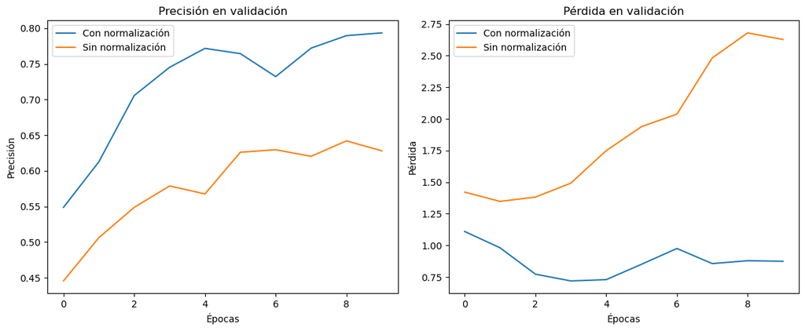

```python
# Comparar precisión entre modelo normalizado y modelo sin normalizar
plt.figure(figsize=(12, 5))

# Precisión
plt.subplot(1, 2, 1)
plt.plot(history.history['val_accuracy'], label='Con normalización')
plt.plot(history_raw.history['val_accuracy'], label='Sin normalización')
plt.title('Precisión en validación')
plt.xlabel('Épocas')
plt.ylabel('Precisión')
plt.legend()

# Pérdida
plt.subplot(1, 2, 2)
plt.plot(history.history['val_loss'], label='Con normalización')
plt.plot(history_raw.history['val_loss'], label='Sin normalización')
plt.title('Pérdida en validación')
plt.xlabel('Épocas')
plt.ylabel('Pérdida')
plt.legend()

plt.tight_layout()
plt.show()
```

#### Conclusión

Al comparar el desempeño del modelo con y sin normalización de imágenes, se observa una mejora significativa en ambos indicadores de rendimiento cuando se aplica normalización.

- Se observa que, el modelo con normalización alcanza una precisión en validación cercana al 80%, mientras que el modelo sin normalización se mantiene por debajo del 65%.
- En la gráfica de pérdida, el modelo con normalización muestra una curva más estable y con valores considerablemente más bajos, lo que indica un mejor ajuste al conjunto de datos de validación.

Estos resultados reflejan que la normalización de los valores de píxeles (de 0-255 a 0-1) ayuda al modelo a entrenar de manera más eficiente, logrando mejores predicciones y menor sobreajuste. Esto se debe a que las redes neuronales suelen converger más rápido y con mayor estabilidad cuando las entradas están en una escala uniforme.